# STA Exam - MSBA Summer’22

#### (c) Does your chosen model involve all of the features in the dataset? Why or why not?

# Chapter 8

### Question 8

We will seek to predict Sales using regression trees and related approaches, treating the response as a quantitative variable.

#### (a) Split the data set into a training set and a test set.

```r
rm(list = ls())
library(ISLR)
library(tidyverse)
library(rpart)
library(tree)
library(randomForest)
set.seed(101)

carseats_dat = Carseats

# splitting dataset with 70:30 split (train-test)
n = carseats_dat %>% nrow
idx = sample(1:n, 0.7*n)


train = carseats_dat[idx,]
# length of training set
nrow(train)
```

```
## [1] 280
```

```r
test = carseats_dat[-idx,]
# length of testing set
nrow(test)
```

```
## [1] 120
```

#### (b) Fit a regression tree to the training set. Plot the tree, and interpret the results. What test error rate do you obtain?

```r
train %>% str
```

```
## 'data.frame':    280 obs. of  11 variables:
##  $ Sales      : num  3.15 6.8 8.39 7.78 8.64 ...
##  $ CompPrice  : num  117 137 115 86 111 122 133 114 133 125 ...
##  $ Income     : num  66 117 97 54 101 36 33 43 31 48 ...
##  $ Advertising: num  1 5 5 0 17 5 10 0 1 3 ...
##  $ Population : num  65 337 134 497 266 369 333 199 80 192 ...
##  $ Price      : num  111 135 84 64 91 72 129 88 145 116 ...
##  $ ShelveLoc  : Factor w/ 3 levels "Bad","Good","Medium": 1 1 1 1 3 2 2 2 3 3 ...
##  $ Age        : num  55 38 55 33 63 35 71 57 42 51 ...
##  $ Education  : num  11 10 11 12 17 10 14 10 18 14 ...
##  $ Urban      : Factor w/ 2 levels "No","Yes": 2 2 2 2 1 2 2 1 2 2 ...
##  $ US         : Factor w/ 2 levels "No","Yes": 2 2 2 1 2 2 2 2 2 2 ...
```

```r
tree_fit = tree(Sales ~ ., data = train)

summary(tree_fit)
```

```
##
## Regression tree:
## tree(formula = Sales ~ ., data = train)
## Variables actually used in tree construction:
## [1] "ShelveLoc"   "Price"       "Age"         "Income"      "Advertising"
## [6] "CompPrice"   "US"
## Number of terminal nodes:  14
## Residual mean deviance:  2.689 = 715.3 / 266
## Distribution of residuals:
##    Min. 1st Qu.  Median    Mean 3rd Qu.    Max.
##  -4.355  -1.041   0.006   0.000   1.000   4.905
```

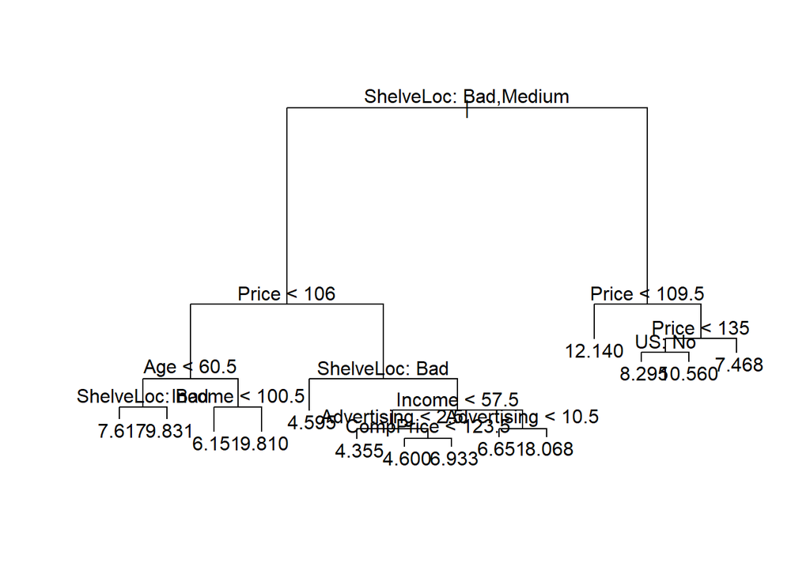

```r
plot(tree_fit)
text(tree_fit, pretty=0)
```

```r
pred_tree = predict(tree_fit, test%>%dplyr::select(-Sales))
MSE_tree = mean((test[,'Sales'] - pred_tree)^2)
cat(MSE_tree)
```

```
## 4.915969
```

Test error is 4.915. Out of the 11 variables, 7 are used to make the tree. ShelveLoc appears to be the most important variable because it used in the root node for the tree split followed by Price, which is is used to create splits at the second level of the tree.

#### (c) Use cross-validation in order to determine the optimal level of tree complexity. Does pruning the tree improve the test error rate?

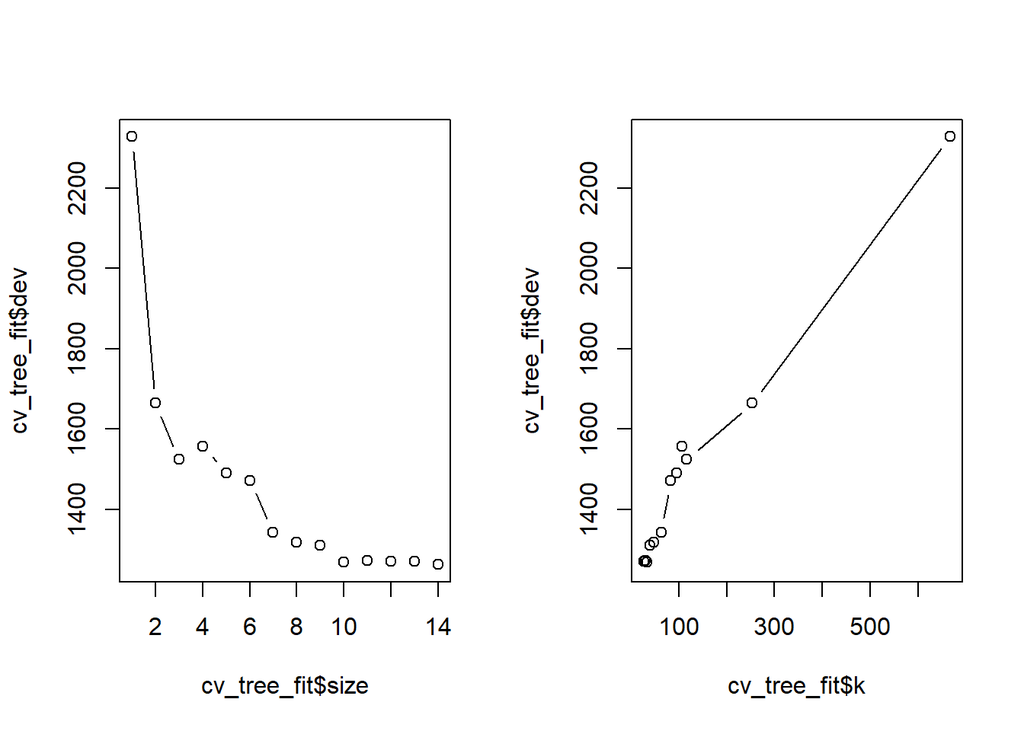

```r
cv_tree_fit = cv.tree(tree_fit, FUN = prune.tree)
par(mfrow = c(1, 2))
plot(cv_tree_fit$size, cv_tree_fit$dev, type = "b")
plot(cv_tree_fit$k, cv_tree_fit$dev, type = "b")
```

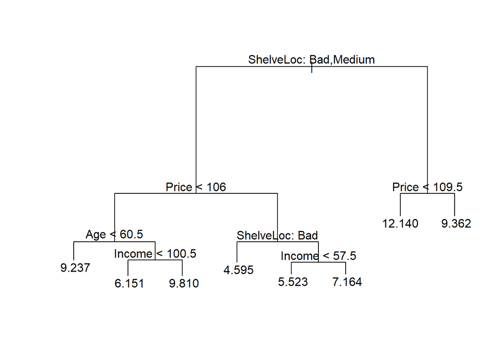

```r
pruned_tree = prune.tree(tree_fit, best = 8)
par(mfrow = c(1, 1))
plot(pruned_tree)
text(pruned_tree, pretty = 0)
```

```r
pred_pruned_tree = predict(pruned_tree, test%>%dplyr::select(-Sales))
MSE_pruned_tree = mean((test[,'Sales'] - pred_pruned_tree)^2)
cat(MSE_pruned_tree)
```

```
## 5.106689
```

Pruning the tree increases test MSE.

#### (d) Use the bagging approach in order to analyze this data. What test error rate do you obtain? Use the importance() function to determine which variables are most important

```r
rf_fit = randomForest(Sales ~ ., data = train, importance = T)
rf_prediction = predict(rf_fit, test%>%dplyr::select(-Sales))
MSE_rf = mean((test[,'Sales'] - rf_prediction)^2)
cat(MSE_rf)
```

```
## 2.894636
```

```r
importance(rf_fit)
```

```
##                %IncMSE IncNodePurity
## CompPrice   12.0172360     188.31225
## Income       4.3452176     161.48257
## Advertising 16.2440037     189.68633
## Population  -1.8003869     145.20881
## Price       41.5614700     551.43929
## ShelveLoc   53.6475512     595.48634
## Age         14.5508718     212.65730
## Education    2.8477140      90.99886
## Urban        0.9014082      18.58106
## US           6.2667113      34.31104
```

Random forest/bagging decreases the MSE and improves the model. Most important variables are - ShelveLoc, Price and Advertising.

#### (e) Use random forests to analyze this data. What test error rate do you obtain? Use the importance() function to determine which variables are most important. Describe the effect of m, the number of variables considered at each split, on the error rate obtained.

```r
rf_fit = randomForest(Sales ~ ., data = train, importance = T, mtry=3) #increasing mtry improves the model
rf_prediction = predict(rf_fit, test%>%dplyr::select(-Sales))
MSE_rf = mean((test[,'Sales'] - rf_prediction)^2)
cat(MSE_rf)
```

```
## 2.89402
```

```r
importance(rf_fit)
```

```
##                %IncMSE IncNodePurity
## CompPrice   12.3805867     188.26368
## Income       4.8364380     163.25233
## Advertising 16.8711925     189.02767
## Population   1.7622390     149.02625
## Price       44.5486037     555.36330
## ShelveLoc   51.4840070     593.38685
## Age         13.1179172     208.79060
## Education    1.5734843      84.82362
## Urban        0.3589163      19.50490
## US           4.9611884      32.36192
```

# Chapter 8

### Question 11

This question uses the Caravan data set.

#### (a) Create a training set consisting of the first 1,000 observations, and a test set consisting of the remaining observations.

```r
rm(list = ls())
library(ISLR)
library(tidyverse)
library(gbm)
set.seed(107)

caravan_dat = Caravan
# caravan_dat %>% str
caravan_dat = caravan_dat %>% mutate(purchase_label = ifelse(Purchase == "Yes", 1, 0))
caravan_dat = caravan_dat %>% dplyr::select(-Purchase)

train = caravan_dat[1:1000,]
test = caravan_dat[1000:nrow(caravan_dat),]
```

#### (b) Fit a boosting model to the training set with Purchase as the response and the other variables as predictors. Use 1,000 trees, and a shrinkage value of 0.01. Which predictors appear to be the most important?

```r
gbm_fit = gbm(purchase_label ~ ., data = train, n.trees = 1000, shrinkage = 0.01)
```

```
## Distribution not specified, assuming bernoulli ...
```

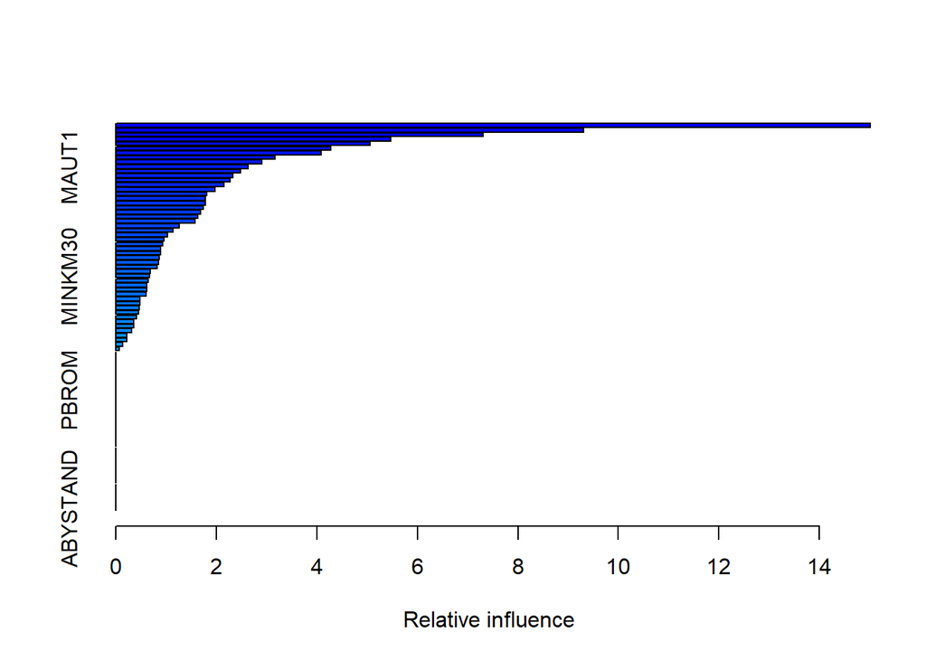

```
##               var     rel.inf
## PPERSAUT PPERSAUT 15.00949288
## MKOOPKLA MKOOPKLA  9.31330624
## MOPLHOOG MOPLHOOG  7.31354135
## MBERMIDD MBERMIDD  5.46412685
## PBRAND     PBRAND  5.05350016
## MGODGE     MGODGE  4.27763318
## ABRAND     ABRAND  4.09160716
## MINK3045 MINK3045  3.16548232
## MOSTYPE   MOSTYPE  2.91321676
## MAUT1       MAUT1  2.63422368
## MAUT2       MAUT2  2.48588446
## MGODPR     MGODPR  2.33502437
## PWAPART   PWAPART  2.28073775
## MSKC         MSKC  2.14800637
## MBERHOOG MBERHOOG  1.97803947
## MSKA         MSKA  1.81351548
## PBYSTAND PBYSTAND  1.78416557
## MBERARBG MBERARBG  1.78266984
## MINKGEM   MINKGEM  1.74515538
## MRELGE     MRELGE  1.69242010
## MGODOV     MGODOV  1.62838163
## MSKB1       MSKB1  1.58201222
## MINK7512 MINK7512  1.26163756
## MRELOV     MRELOV  1.14516310
## MFGEKIND MFGEKIND  1.03379422
## MFWEKIND MFWEKIND  0.95475561
## MSKD         MSKD  0.93592796
## MBERBOER MBERBOER  0.89708790
## MHHUUR     MHHUUR  0.89375115
## MAUT0       MAUT0  0.87075206
## MGODRK     MGODRK  0.84551666
## MHKOOP     MHKOOP  0.83054456
## MZPART     MZPART  0.69206757
## MINKM30   MINKM30  0.67323829
## PMOTSCO   PMOTSCO  0.64292304
## MOSHOOFD MOSHOOFD  0.61773355
## MGEMLEEF MGEMLEEF  0.61396826
## MOPLMIDD MOPLMIDD  0.60766060
## MGEMOMV   MGEMOMV  0.48794508
```

[output cut: 31 more lines]

```
## AMOTSCO   AMOTSCO  0.00000000
## AVRAAUT   AVRAAUT  0.00000000
## AAANHANG AAANHANG  0.00000000
## ATRACTOR ATRACTOR  0.00000000
## AWERKT     AWERKT  0.00000000
## ABROM       ABROM  0.00000000
## ALEVEN     ALEVEN  0.00000000
## APERSONG APERSONG  0.00000000
## AGEZONG   AGEZONG  0.00000000
## AWAOREG   AWAOREG  0.00000000
## AZEILPL   AZEILPL  0.00000000
## APLEZIER APLEZIER  0.00000000
## AFIETS     AFIETS  0.00000000
## AINBOED   AINBOED  0.00000000
## ABYSTAND ABYSTAND  0.00000000
```

```r
summary(gbm_fit)
```

**PPERSAUT** and **MKOOPKLA** is the most important variables

#### (c) Use the boosting model to predict the response on the test data. Predict that a person will make a purchase if the estimated probability of purchase is greater than 20 %. Form a confusion matrix. What fraction of the people predicted to make a purchase do in fact make one? How does this compare with the results obtained from applying KNN or logistic regression to this data set?

```r
set.seed(123)
gbm_prob = predict(gbm_fit, test %>% dplyr::select(-purchase_label), type ="response")
gbm_preds = ifelse(gbm_prob > 0.2, 1, 0)
table(test$purchase_label, gbm_preds)
```

```
##    gbm_preds
##        0    1
##   0 4425  109
##   1  257   32
```

```r
32/(109 + 32)
```

```
## [1] 0.2269504
```

```r
# lm fit
lm_fit = lm(purchase_label ~ ., data = train, family = binomial)

lm_prob = predict(lm_fit, test %>% dplyr::select(-purchase_label), type ="response")
lm_preds = ifelse(lm_prob > 0.2, 1, 0)
table(test$purchase_label, lm_preds)
```

```
##    lm_preds
##        0    1
##   0 4407  127
##   1  253   36
```

```r
36/(127+36)
```

```
## [1] 0.2208589
```

# Chapter 10

### Question 7

In the chapter, we mentioned the use of correlation-based distance and Euclidean distance as dissimilarity measures for hierarchical clustering. It turns out that these two measures are almost equivalent: if each observation has been centered to have mean zero and standard deviation one, and if we let rij denote the correlation between the ith and jth observations, then the quantity 1 − rij is proportional to the squared Euclidean distance between the ith and jth observations. On the USArrests data, show that this proportionality holds. Hint: The Euclidean distance can be calculated using the dist() function, and correlations can be calculated using the cor() function.

```r
rm(list = ls())
library(ISLR)
library(tidyverse)

set.seed(108)

usarrests_dat = USArrests
usarrests_dat %>% str
```

```
## 'data.frame':    50 obs. of  4 variables:
##  $ Murder  : num  13.2 10 8.1 8.8 9 7.9 3.3 5.9 15.4 17.4 ...
##  $ Assault : int  236 263 294 190 276 204 110 238 335 211 ...
##  $ UrbanPop: int  58 48 80 50 91 78 77 72 80 60 ...
##  $ Rape    : num  21.2 44.5 31 19.5 40.6 38.7 11.1 15.8 31.9 25.8 ...
```

```r
scaled_US_arrests = scale(USArrests)

dist_mat = dist(t(scaled_US_arrests))

# These match with one another so they are in proportion
1 - cor(usarrests_dat)
```

```
##             Murder   Assault  UrbanPop      Rape
## Murder   0.0000000 0.1981267 0.9304274 0.4364212
## Assault  0.1981267 0.0000000 0.7411283 0.3347588
## UrbanPop 0.9304274 0.7411283 0.0000000 0.5886588
## Rape     0.4364212 0.3347588 0.5886588 0.0000000
```

```r
dist_mat^2
```

```
##            Murder  Assault UrbanPop
## Assault  19.41642
## UrbanPop 91.18188 72.63057
## Rape     42.76927 32.80636 57.68856
```

# Exam Problems

### Problem 1: Beauty Pays!

#### 1. Using the data, estimate the effect of “beauty” into course ratings. Make sure to think about the potential many “other determinants”. Describe your analysis and your conclusions.

```r
rm(list = ls())
library(tidyverse)

set.seed(108)

beauty_dat = as.tibble(read.csv("BeautyData.csv"))

lm_fit = lm(CourseEvals  ~., data=beauty_dat)

summary(lm_fit)
```

```
##
## Call:
## lm(formula = CourseEvals ~ ., data = beauty_dat)
##
## Residuals:
##      Min       1Q   Median       3Q      Max
## -1.31385 -0.30202  0.01011  0.29815  1.04929
##
## Coefficients:
##             Estimate Std. Error t value Pr(>|t|)
## (Intercept)  4.06542    0.05145  79.020  < 2e-16 ***
## BeautyScore  0.30415    0.02543  11.959  < 2e-16 ***
## female      -0.33199    0.04075  -8.146 3.62e-15 ***
## lower       -0.34255    0.04282  -7.999 1.04e-14 ***
## nonenglish  -0.25808    0.08478  -3.044  0.00247 **
## tenuretrack -0.09945    0.04888  -2.035  0.04245 *
## ---
## Signif. codes:  0 '***' 0.001 '**' 0.01 '*' 0.05 '.' 0.1 ' ' 1
##
## Residual standard error: 0.4273 on 457 degrees of freedom
## Multiple R-squared:  0.3471, Adjusted R-squared:  0.3399
## F-statistic: 48.58 on 5 and 457 DF,  p-value: < 2.2e-16
```

- BeautyScore, female, lower and nonenglish are all significant while predicting the Evaluation Score
- Beauty affects the evaluation scores significantly
- Females score lower in evaluations - there is no possible explanation for this
- non-english speakers will have difficult time in communicating ideas so the scores for them will be lower
- evaluations from lower division classes are less, because people taking these classes might not be interested in them

#### 2. In his paper, Dr. Hamermesh has the following sentence: “Disentangling whether this outcome represents productivity or discrimination is, as with the issue generally, probably impossible”. Using the concepts we have talked about so far, what does he mean by that?

One cannot say with certainty that Beauty affects evaluation scores, there appears to be discrimination against females. But all in all there are many other factors that influence evaluation scores like english speaking, teaching lower division subjects etc. which can affect beauty according to the summary of regression model fit shown in the previous answer

### Problem 2: Housing Price Structure

The file MidCity.xls, available on the class website, contains data on 128 recent sales of houses in a town. For each sale, the file shows the neighborhood in which the house is located, the number of offers made on the house, the square footage, whether the house is made out of brick, the number of bathrooms, the number of bedrooms, and the selling price. Neighborhoods 1 and 2 are more traditional whereas 3 is a more modern, newer and more prestigious part of town. Use regression models to estimate the pricing structure of houses in this town and answer the following questions

#### 1. Is there a premium for brick houses everything else being equal?

```r
rm(list = ls())
library(tidyverse)
set.seed(111)

midcity_dat = as.tibble(read.csv("MidCity.csv"))
# midcity_dat %>% str

midcity_dat = midcity_dat %>% mutate(Brick = ifelse(Brick == "Yes",1,0))

midcity_dat
```

```
## # A tibble: 128 × 8
##     Home  Nbhd Offers  SqFt Brick Bedrooms Bathrooms  Price
##    <int> <int>  <int> <int> <dbl>    <int>     <int>  <int>
##  1     1     2      2  1790     0        2         2 114300
##  2     2     2      3  2030     0        4         2 114200
##  3     3     2      1  1740     0        3         2 114800
##  4     4     2      3  1980     0        3         2  94700
##  5     5     2      3  2130     0        3         3 119800
##  6     6     1      2  1780     0        3         2 114600
##  7     7     3      3  1830     1        3         3 151600
##  8     8     3      2  2160     0        4         2 150700
##  9     9     2      3  2110     0        4         2 119200
## 10    10     2      3  1730     0        3         3 104000
## # … with 118 more rows
```

```r
lm_fit = lm(Price  ~ ., data=midcity_dat)

summary(lm_fit)
```

```
##
## Call:
## lm(formula = Price ~ ., data = midcity_dat)
##
## Residuals:
##      Min       1Q   Median       3Q      Max
## -24940.6  -8383.0    430.7   7430.4  31371.2
##
## Coefficients:
##              Estimate Std. Error t value Pr(>|t|)
## (Intercept) -9814.663   9858.884  -0.996  0.32149
## Home            6.187     28.973   0.214  0.83128
## Nbhd         9832.281   1821.869   5.397 3.47e-07 ***
## Offers      -8351.794   1267.428  -6.590 1.24e-09 ***
## SqFt           49.811      6.769   7.359 2.53e-11 ***
## Brick       15601.818   2261.896   6.898 2.66e-10 ***
## Bedrooms     5671.911   1840.979   3.081  0.00256 **
## Bathrooms    8243.545   2449.897   3.365  0.00103 **
## ---
## Signif. codes:  0 '***' 0.001 '**' 0.01 '*' 0.05 '.' 0.1 ' ' 1
##
## Residual standard error: 11540 on 120 degrees of freedom
## Multiple R-squared:  0.8256, Adjusted R-squared:  0.8154
## F-statistic: 81.15 on 7 and 120 DF,  p-value: < 2.2e-16
```

People are willing to pay premium for a brick home. As Brick is +ve in the summary of lm_fit and its p-value < 0.05 which makes it significant.

#### 2. Is there a premium for houses in neighborhood 3?

```r
# adding dummy for neighborhood 3
midcity_dat = midcity_dat %>% mutate(Nbhd3 = ifelse(Nbhd == 3,1,0))

lm_fit = lm(Price  ~ ., data=midcity_dat)

summary(lm_fit)
```

```
##
## Call:
## lm(formula = Price ~ ., data = midcity_dat)
##
## Residuals:
##      Min       1Q   Median       3Q      Max
## -27897.8  -6074.8    -48.7   5551.8  27536.4
##
## Coefficients:
##              Estimate Std. Error t value Pr(>|t|)
## (Intercept)  3767.339   8854.757   0.425 0.671270
## Home          -11.456     25.387  -0.451 0.652616
## Nbhd        -1729.613   2433.756  -0.711 0.478675
## Offers      -8350.128   1103.693  -7.566 8.96e-12 ***
## SqFt           53.634      5.926   9.051 3.30e-15 ***
## Brick       17313.540   1988.548   8.707 2.12e-14 ***
## Bedrooms     4136.461   1621.775   2.551 0.012023 *
## Bathrooms    7975.157   2133.831   3.737 0.000287 ***
## Nbhd3       23993.932   3830.057   6.265 6.17e-09 ***
## ---
## Signif. codes:  0 '***' 0.001 '**' 0.01 '*' 0.05 '.' 0.1 ' ' 1
##
## Residual standard error: 10050 on 119 degrees of freedom
## Multiple R-squared:  0.8688, Adjusted R-squared:   0.86
## F-statistic: 98.54 on 8 and 119 DF,  p-value: < 2.2e-16
```

There is a premium for Neighborhood 3. Dummy variable Nbhd3 is positive and has a p-value < 0.05 so it is statistically significant.

#### 3. Is there an extra premium for brick houses in neighborhood 3?

```r
# adding dummy for neighborhood 3 and brick houses
midcity_dat = midcity_dat %>% mutate(Nbhd3_brick = ifelse((Nbhd == 3) & (Brick == 1),1, 0))


lm_fit = lm(Price  ~ ., data=midcity_dat)

summary(lm_fit)
```

```
##
## Call:
## lm(formula = Price ~ ., data = midcity_dat)
##
## Residuals:
##      Min       1Q   Median       3Q      Max
## -27515.9  -5681.0   -459.6   4451.0  26695.6
##
## Coefficients:
##              Estimate Std. Error t value Pr(>|t|)
## (Intercept)  3731.658   8676.193   0.430  0.66791
## Home          -11.799     24.875  -0.474  0.63613
## Nbhd         -846.146   2412.025  -0.351  0.72636
## Offers      -8486.348   1082.875  -7.837 2.26e-12 ***
## SqFt           54.726      5.823   9.397 5.36e-16 ***
## Brick       13839.320   2413.580   5.734 7.69e-08 ***
## Bedrooms     4605.046   1600.639   2.877  0.00477 **
## Bathrooms    6556.432   2170.200   3.021  0.00309 **
## Nbhd3       18779.206   4319.105   4.348 2.93e-05 ***
## Nbhd3_brick 10192.783   4178.971   2.439  0.01621 *
## ---
## Signif. codes:  0 '***' 0.001 '**' 0.01 '*' 0.05 '.' 0.1 ' ' 1
##
## Residual standard error: 9850 on 118 degrees of freedom
## Multiple R-squared:  0.8751, Adjusted R-squared:  0.8656
## F-statistic:  91.9 on 9 and 118 DF,  p-value: < 2.2e-16
```

Nbhd3_brick shows a statistical significance with 95% confidence. So neighborhood 3 with Brick houses do have a premium. But if we consider a broader confidence interval of 99% then it is not statistically significant.

#### 4. For the purposes of prediction could you combine the neighborhoods 1 and 2 into a single “older” neighborhood?

```r
# adding dummy for neighborhood 3 and brick houses
midcity_dat_nbhd = midcity_dat %>% mutate(Nbhd2 = ifelse(Nbhd == 2, 1, 0), Nbhd1 = ifelse(Nbhd == 1, 1, 0)) %>% dplyr::select(-c(Nbhd3_brick,  Nbhd))


lm_fit = lm(Price  ~ ., data=midcity_dat_nbhd)

summary(lm_fit)
```

```
##
## Call:
## lm(formula = Price ~ ., data = midcity_dat_nbhd)
##
## Residuals:
##      Min       1Q   Median       3Q      Max
## -27897.8  -6074.8    -48.7   5551.8  27536.4
##
## Coefficients: (1 not defined because of singularities)
##              Estimate Std. Error t value Pr(>|t|)
## (Intercept)  2037.726   8911.501   0.229 0.819524
## Home          -11.456     25.387  -0.451 0.652616
## Offers      -8350.128   1103.693  -7.566 8.96e-12 ***
## SqFt           53.634      5.926   9.051 3.30e-15 ***
## Brick       17313.540   1988.548   8.707 2.12e-14 ***
## Bedrooms     4136.461   1621.775   2.551 0.012023 *
## Bathrooms    7975.157   2133.831   3.737 0.000287 ***
## Nbhd3       20534.706   3176.051   6.465 2.33e-09 ***
## Nbhd2       -1729.613   2433.756  -0.711 0.478675
## Nbhd1              NA         NA      NA       NA
## ---
## Signif. codes:  0 '***' 0.001 '**' 0.01 '*' 0.05 '.' 0.1 ' ' 1
##
## Residual standard error: 10050 on 119 degrees of freedom
## Multiple R-squared:  0.8688, Adjusted R-squared:   0.86
## F-statistic: 98.54 on 8 and 119 DF,  p-value: < 2.2e-16
```

Nbhd1 in the presence of Nbhd2 and Nbhd3 results in singularity. Therefore Nbhd1 and Nbhd2 can be clubbed together as ‘older’.

### Problem 3: What causes what??

#### 1. Why can’t I just get data from a few different cities and run the regression of “Crime” on “Police” to understand how more cops in the streets affect crime? (“Crime” refers to some measure of crime rate and “Police” measures the number of cops in a city)

This will not tell us if more police leads to more crime or more crime leads to more police. It will only tell us the correlation between “crime” and “police”

#### 2. How were the researchers from UPENN able to isolate this effect? Briefly describe their approach and discuss their result in the “Table 2” below.

The researchers used natural experiment. According to the table crime decreases on high alert and goes up if the METRO ridership goes up. Since criminals will also not venture out in case of an orange alert/terrorist threat. To test this hypothesis they wanted to check if the METRO ridership dips during a terrorist threat. So they decided to use that as a control.

#### 3. Why did they have to control for METRO ridership? What was that trying to capture?

Eventually they found out that METRO ridership remains unchanged during terrorist threats, so the effect of more cops on causing a decrease in criminals on the street could be significant. Because it was being assumed that criminals might not go out doing crimes during a terrorist alert due to increased cop activity, but this was verified with METRO ridership and this hypothesis was rejected, because METRO ridership was unchanged during high alerts.

#### 4. In the next page, I am showing you “Table 4” from the research paper. Just focus on the first column of the table. Can you describe the model being estimated here? What is the conclusion?

High alert at district 1 (a variable with interaction terms) is highly significant. This tells us that more cops in the district 1 in times of high alert results in decreased criminal activity.

### Problem 5: Final Project

I contributed by selecting the dataset for our problem and resentation from kaggle and running hyperparameter tuning for XGB using Bayesian optimization and single layer neural net. All the members of our team were responsible for trying out different classification techniques to see which one gives the best accuracy. Our problem statement was to predict credit card approvals. Since this problem has a highly imbalanced class our objective was to optimize for recall rather than the overall accuracy. Therefore we needed to select a modeling technique that outputs a higher recall value irrespective of the class imbalance. Since random forest and logistic regression were not giving us the expected results, we decided to use XGB.

Our dataset contains ~400K rows and ~25 columns (after creating dummies of the categorical columns). Since this is a big dataset, tuning the XGB hyperparameters using grid search or random search took a lot of time and did not output the expected results. Therefore, to work with the limited compute power and time I decided to use Bayesian optimization to find the optimal parameters quickly. the resulting model improved the model AUC from lower ~80% to upper ~90%. This also translated to increasing the recall score significantly after using the correct threhold to distinguish between the positive and negative classes.

After obtaining the required recall value, I decided to try a single layer neural net to see if the model can be improved. Just a single layer neural net was able to output a recall of 65% without any hyperparameter tuning. As the next steps I have decided to use bayesian optmization to tune the deep neural net paramters to improve the model.